# Biostat 203B Homework 3

Due Feb 23 @ 11:59PM

Author

Bowen Zhang UID: 506126821

Display machine information for reproducibility:

```r
#|eval = True

sessionInfo()
```

[output not shown]

Load necessary libraries (you can add more as needed).

```r
library(arrow)
library(memuse)
library(pryr)
library(R.utils)
library(tidyverse)
```

Display your machine memory.

```r
memuse::Sys.meminfo()
```

[output not shown]

In this exercise, we use tidyverse (ggplot2, dplyr, etc) to explore the [MIMIC-IV](https://mimic.mit.edu/docs/iv/) data introduced in [homework 1](https://ucla-biostat-203b.github.io/2024winter/hw/hw1/hw1.html) and to build a cohort of ICU stays.

## Q1. Visualizing patient trajectory

Visualizing a patient’s encounters in a health care system is a common task in clinical data analysis. In this question, we will visualize a patient’s ADT (admission-discharge-transfer) history and ICU vitals in the MIMIC-IV data.

### Q1.1 ADT history

Do a similar visualization for the patient with `subject_id` 10013310 using ggplot.

Hint: We need to pull information from data files `patients.csv.gz`, `admissions.csv.gz`, `transfers.csv.gz`, `labevents.csv.gz`, `procedures_icd.csv.gz`, `diagnoses_icd.csv.gz`, `d_icd_procedures.csv.gz`, and `d_icd_diagnoses.csv.gz`. For the big file `labevents.csv.gz`, use the Parquet format you generated in Homework 2. For reproducibility, make the Parquet folder `labevents_pq` available at the current working directory `hw3`, for example, by a symbolic link. Make your code reproducible.

**Answer:**

```bash
# I have use symbolic link to make parquet file available at current location
ls -l
```

```
total 167008
-rw-r--r-- 1 bowenzhangstats bowenzhangstats     97025 Feb 10 16:46 10001217_adt.png
-rw-r--r-- 1 bowenzhangstats bowenzhangstats    281956 Feb 10 16:46 10001217_icu.png
-rw-r--r-- 1 bowenzhangstats bowenzhangstats 165947572 Feb 14 18:59 chartevents_filtered.csv.gz
-rw-r--r-- 1 bowenzhangstats bowenzhangstats    178879 Feb 10 16:46 chartevents_tble.png
-rw-r--r-- 1 bowenzhangstats bowenzhangstats   3884459 Feb 15 19:20 hw3.html
-rw-r--r-- 1 bowenzhangstats bowenzhangstats     23057 Feb 15 19:32 hw3.qmd
-rw-r--r-- 1 bowenzhangstats bowenzhangstats     23105 Feb 15 19:32 hw3.rmarkdown
lrwxrwxrwx 1 bowenzhangstats bowenzhangstats        67 Feb 12 10:26 labevents_pq -> /home/bowenzhangstats/CourseMaterials/203b-hw/hw2/labevents.parquet
-rw-r--r-- 1 bowenzhangstats bowenzhangstats    172738 Feb 10 16:46 labevents_tble.png
-rw-r--r-- 1 bowenzhangstats bowenzhangstats    387253 Feb 10 16:46 mimic_icu_cohort.png
```

```r
patient_id <- 10013310

# Read patients.csv.gz, and extract the info for title
patients_info <- read_csv("~/mimic/hosp/patients.csv.gz",
                          show_col_types = F) |>
  filter(subject_id == patient_id) |>
  select(subject_id, gender, anchor_age)

# Read diagnoses_icd.csv.gz, and extract the info for subtitle
patients_diagnose <- read_csv("~/mimic/hosp/diagnoses_icd.csv.gz",
                              show_col_types = F) |>
  filter(subject_id == patient_id & seq_num <= 3)

# Read d_icd_diagnoses.csv.gz to get the name of diagnoses
diagnoses <- read_csv("~/mimic/hosp/d_icd_diagnoses.csv.gz",
                      show_col_types = F)

# Match the diagnose to the coding in patients_diagnose
patients_diagnose <- left_join(patients_diagnose, diagnoses,
                               by = c("icd_code", "icd_version"))
rm(diagnoses)

# Read procedures_icd.csv.gz, and extract the info for procedure
patients_procedure <- read_csv("~/mimic/hosp/procedures_icd.csv.gz",
                               show_col_types = F) |>
  filter(subject_id == patient_id) |>
  mutate(chartdate = as.POSIXct(chartdate))

# Read d_icd_procedures.csv.gz to get the name of procedures
procedure <- read_csv("~/mimic/hosp/d_icd_procedures.csv.gz",
                      show_col_types = F)

# Match the procedure to the coding in patients_procedure
patients_procedure <- left_join(patients_procedure, procedure,
                                by = c("icd_code", "icd_version")) |>
  mutate(Procedure = str_extract(long_title, "[^,]+"))


rm(procedure)

# Read admissions.csv.gz, and extract info for title(race)
patients_info$race <- read_csv("~/mimic/hosp/admissions.csv.gz",
                               show_col_types = F) |>
  filter(subject_id == patient_id) |>
  select("race") |>
  distinct() %>% .$race

# Read transfers.csv.gz, and extract info for ADT
# Notice we need ICU/CCU, which can be detected from careunit
patients_adt <- read_csv("~/mimic/hosp/transfers.csv.gz",
                         show_col_types = F) |>
  filter(subject_id == patient_id & eventtype != "discharge") |>
  select(-"transfer_id") |>
  arrange(intime) |>
  mutate(ICU_CCU = str_detect(careunit, 'CU'))


# Read labevents_pq, and extract info for Lab
patients_lab <- arrow::open_dataset("./labevents_pq", format = 'parquet') |>
  filter(subject_id == patient_id) |>
  select(charttime) |>
  collect() |>
  distinct()

# This is the function to get the title line
generate_title <- function(info){
  subject_id <- str_c("Patient ", as.character(info[1,"subject_id"]))
  gender <- as.character(info[1, "gender"])
  age <- str_c(as.character(info[1, "anchor_age"]), " years old")
  return(str_c(subject_id, gender, age, str_to_lower(info[1, "race"]),
               sep = ", "))
}

# We want to show the diagnoses when the patient was firstly admitted
arrange_hadm_id <- arrange(patients_adt, intime) %>% .$hadm_id
patients_diagnose <- filter(patients_diagnose, hadm_id == arrange_hadm_id[1])

title <- generate_title(patients_info)

subtitle <- str_c(patients_diagnose[1, "long_title"],
                  patients_diagnose[2, "long_title"],
                  patients_diagnose[3, "long_title"], sep = "\n")

number_of_procedure <- patients_procedure |>
  select(Procedure) |>
  distinct() |>
  nrow()
```

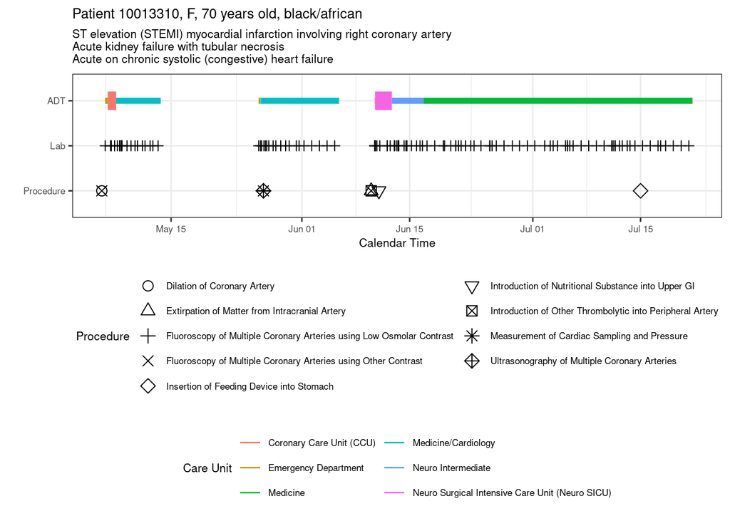

```r
# Draw the plot with the information above

time_range <- c(patients_adt[[1, "intime"]],
                patients_adt[[nrow(patients_adt), "outtime"]])

empty_data <- tibble(CalenderTime = c(time_range, NA),
                     Information = c("ADT", "Lab", "Procedure"))

empty_data$Information <- factor(empty_data$Information,
                                 levels = c("Procedure", "Lab", "ADT"))

ggplot(empty_data, mapping = aes(x = CalenderTime, y = Information)) +
  geom_blank() +
  geom_point(data = patients_lab, mapping = aes(x = charttime, y = "Lab"),
             shape = 3, size = 2) +
  geom_point(data = patients_procedure,
             mapping = aes(x = chartdate,
                           y = "Procedure",
                           shape = Procedure),
             size = 3) +
  geom_segment(data = patients_adt, aes(x = intime, xend = outtime,
                                        y = "ADT", yend = "ADT",
                                        color = careunit,
                                        linewidth = ICU_CCU)) +
  theme_bw() +
  theme(legend.position="bottom", legend.box = "vertical",
        text = element_text(size = 8)) +
  guides(shape = guide_legend(ncol = 2, order = 1),
         color = guide_legend(ncol = 2, order = 2),
         linewidth = FALSE) +
  labs(title = title,
       subtitle = subtitle,
       color = "Care Unit",
       x = "Calendar Time", y = "") +
   scale_shape_manual(values = c(1:number_of_procedure))
```

Notice that, this patient has been admitted to the hospital three times, and each hospitalization has different diagnoses. Thus, we choose the top 3 diagnoses of the first hospitalization. Since the name of those procedures are too long, I use a shortened version. In addition, there are 9 kinds of procedures in this patients, so it is not a good idea to put all the procedures on the plot, since is it hard to differentiate the legend. The better idea is to select the most important ones according to some medical knowledge. However, for this plot, I just simply put everything on it.

### Q1.2 ICU stays

Do a similar visualization for the patient `10013310`.

```bash
# Extract the required columns and rows from chartevents.csv.gz
zcat < ~/mimic/icu/chartevents.csv.gz | \
awk -F, 'BEGIN{OFS = ","} {
  if ($7 == 220045 || $7 == 220180 || $7 == 220179 ||
      $7 == 223761 || $7 == 220210)
  {
    print $0
  }
}' | gzip > chartevents_filtered.csv.gz
```

```r
rm(list = ls())

patient_id <- 10013310

# Read icustays.csv.gz and get the info for this patient
icu_stay <- read_csv("~/mimic/icu/icustays.csv.gz",
                     show_col_types = F) |>
  filter(subject_id == patient_id) |>
  arrange(intime)

# Read d_items.csv.gz to get the code for HR, NBPd, NBPs, RR, Temperature F
items <- read_csv("~/mimic/icu/d_items.csv.gz",
                  show_col_types = F) |>
  filter(abbreviation %in% c("HR", "NBPd", "NBPs", "RR", "Temperature F")) |>
  select(itemid, label, abbreviation)

# Read chartevents.csv.gz and get vitals for this patient
vital <- read_csv("./chartevents_filtered.csv.gz",
                  col_names = c('subject_id', 'hadm_id',
                                'stay_id', 'caregiver_id',
                                'charttime', 'storetime',
                                'itemid', 'value',
                                'valuenum', 'valueuom', 'warning'),
                  show_col_types = F) |>
  filter(subject_id == patient_id) |>
  left_join(items, by = "itemid") |>
  group_by(stay_id)
```

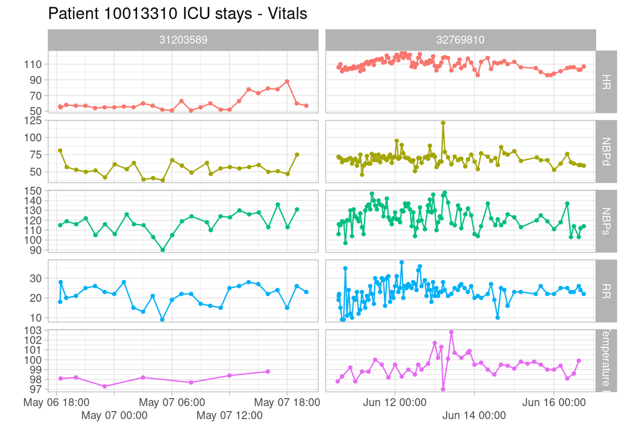

```r
title <- str_c("Patient", as.character(patient_id), "ICU stays - Vitals",
               sep = " ")

ggplot(data = vital) +
  geom_line(mapping = aes(x = charttime, y = valuenum, color = abbreviation),
            show.legend = FALSE) +
  geom_point(mapping = aes(x = charttime, y = valuenum,
                           color = abbreviation), size = 1,
             show.legend = FALSE) +
  facet_grid(abbreviation ~ stay_id, scales = "free") +
  theme_light() +
  labs(title = title, x = "", y = "") +
    scale_x_datetime(date_labels = "%b %d %H:%M") +
  guides(x = guide_axis(n.dodge = 2))
```

## Q2. ICU stays

`icustays.csv.gz` (https://mimic.mit.edu/docs/iv/modules/icu/icustays/) contains data about Intensive Care Units (ICU) stays. The first 10 lines are

```bash
zcat < ~/mimic/icu/icustays.csv.gz | head
```

```
subject_id,hadm_id,stay_id,first_careunit,last_careunit,intime,outtime,los
10000032,29079034,39553978,Medical Intensive Care Unit (MICU),Medical Intensive Care Unit (MICU),2180-07-23 14:00:00,2180-07-23 23:50:47,0.4102662037037037
10000980,26913865,39765666,Medical Intensive Care Unit (MICU),Medical Intensive Care Unit (MICU),2189-06-27 08:42:00,2189-06-27 20:38:27,0.4975347222222222
10001217,24597018,37067082,Surgical Intensive Care Unit (SICU),Surgical Intensive Care Unit (SICU),2157-11-20 19:18:02,2157-11-21 22:08:00,1.1180324074074075
10001217,27703517,34592300,Surgical Intensive Care Unit (SICU),Surgical Intensive Care Unit (SICU),2157-12-19 15:42:24,2157-12-20 14:27:41,0.9481134259259258
10001725,25563031,31205490,Medical/Surgical Intensive Care Unit (MICU/SICU),Medical/Surgical Intensive Care Unit (MICU/SICU),2110-04-11 15:52:22,2110-04-12 23:59:56,1.338587962962963
10001884,26184834,37510196,Medical Intensive Care Unit (MICU),Medical Intensive Care Unit (MICU),2131-01-11 04:20:05,2131-01-20 08:27:30,9.171817129629629
10002013,23581541,39060235,Cardiac Vascular Intensive Care Unit (CVICU),Cardiac Vascular Intensive Care Unit (CVICU),2160-05-18 10:00:53,2160-05-19 17:33:33,1.3143518518518518
10002155,20345487,32358465,Medical Intensive Care Unit (MICU),Medical Intensive Care Unit (MICU),2131-03-09 21:33:00,2131-03-10 18:09:21,0.8585763888888889
10002155,23822395,33685454,Coronary Care Unit (CCU),Coronary Care Unit (CCU),2129-08-04 12:45:00,2129-08-10 17:02:38,6.178912037037037
```

### Q2.1 Ingestion

Import `icustays.csv.gz` as a tibble `icustays_tble`.

```r
rm(list = ls())

icustays_tble <- read_csv("~/mimic/icu/icustays.csv.gz",
                          show_col_types = FALSE)

head(icustays_tble, width = Inf)
```

```
# A tibble: 6 × 8
  subject_id  hadm_id  stay_id first_careunit  last_careunit intime
       <dbl>    <dbl>    <dbl> <chr>           <chr>         <dttm>
1   10000032 29079034 39553978 Medical Intens… Medical Inte… 2180-07-23 14:00:00
2   10000980 26913865 39765666 Medical Intens… Medical Inte… 2189-06-27 08:42:00
3   10001217 24597018 37067082 Surgical Inten… Surgical Int… 2157-11-20 19:18:02
4   10001217 27703517 34592300 Surgical Inten… Surgical Int… 2157-12-19 15:42:24
5   10001725 25563031 31205490 Medical/Surgic… Medical/Surg… 2110-04-11 15:52:22
6   10001884 26184834 37510196 Medical Intens… Medical Inte… 2131-01-11 04:20:05
# ℹ 2 more variables: outtime <dttm>, los <dbl>
```

### Q2.2 Summary and visualization

How many unique `subject_id`? Can a `subject_id` have multiple ICU stays? Summarize the number of ICU stays per `subject_id` by graphs.

```r
# Count how many unique subject_id
icustays_tble |>
  count(subject_id) |>
  nrow()
```

```
[1] 50920
```

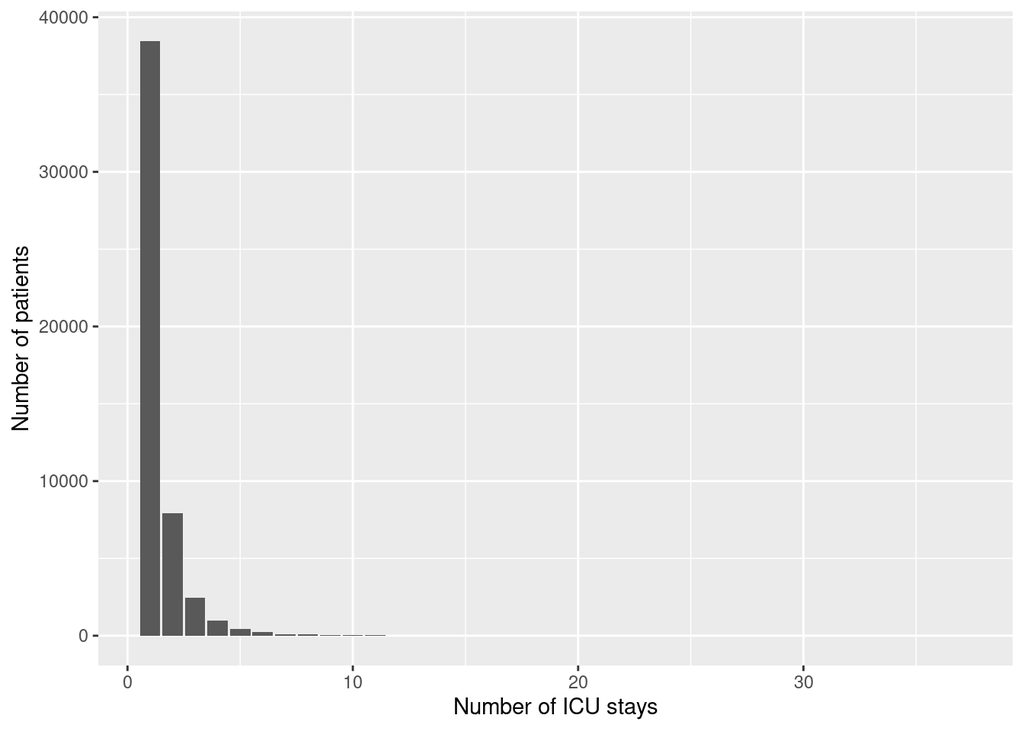

```r
icustays_tble |>
  count(subject_id) |>
  ggplot(aes(x = n)) +
  geom_bar() +
  labs(x = "Number of ICU stays", y = "Number of patients")
```

**Answer:** There are 50920 unique `subject_id`. A `subject_id` can have multiple ICU stays. The graph shows that most of the patients have only one ICU stay. However, there are some patients who have more than one ICU stay. There are even several patients who have more than 10 ICU stays.

## Q3. `admissions` data

Information of the patients admitted into hospital is available in `admissions.csv.gz`. See https://mimic.mit.edu/docs/iv/modules/hosp/admissions/ for details of each field in this file. The first 10 lines are

```bash
zcat < ~/mimic/hosp/admissions.csv.gz | head
```

```
subject_id,hadm_id,admittime,dischtime,deathtime,admission_type,admit_provider_id,admission_location,discharge_location,insurance,language,marital_status,race,edregtime,edouttime,hospital_expire_flag
10000032,22595853,2180-05-06 22:23:00,2180-05-07 17:15:00,,URGENT,P874LG,TRANSFER FROM HOSPITAL,HOME,Other,ENGLISH,WIDOWED,WHITE,2180-05-06 19:17:00,2180-05-06 23:30:00,0
10000032,22841357,2180-06-26 18:27:00,2180-06-27 18:49:00,,EW EMER.,P09Q6Y,EMERGENCY ROOM,HOME,Medicaid,ENGLISH,WIDOWED,WHITE,2180-06-26 15:54:00,2180-06-26 21:31:00,0
10000032,25742920,2180-08-05 23:44:00,2180-08-07 17:50:00,,EW EMER.,P60CC5,EMERGENCY ROOM,HOSPICE,Medicaid,ENGLISH,WIDOWED,WHITE,2180-08-05 20:58:00,2180-08-06 01:44:00,0
10000032,29079034,2180-07-23 12:35:00,2180-07-25 17:55:00,,EW EMER.,P30KEH,EMERGENCY ROOM,HOME,Medicaid,ENGLISH,WIDOWED,WHITE,2180-07-23 05:54:00,2180-07-23 14:00:00,0
10000068,25022803,2160-03-03 23:16:00,2160-03-04 06:26:00,,EU OBSERVATION,P51VDL,EMERGENCY ROOM,,Other,ENGLISH,SINGLE,WHITE,2160-03-03 21:55:00,2160-03-04 06:26:00,0
10000084,23052089,2160-11-21 01:56:00,2160-11-25 14:52:00,,EW EMER.,P6957U,WALK-IN/SELF REFERRAL,HOME HEALTH CARE,Medicare,ENGLISH,MARRIED,WHITE,2160-11-20 20:36:00,2160-11-21 03:20:00,0
10000084,29888819,2160-12-28 05:11:00,2160-12-28 16:07:00,,EU OBSERVATION,P63AD6,PHYSICIAN REFERRAL,,Medicare,ENGLISH,MARRIED,WHITE,2160-12-27 18:32:00,2160-12-28 16:07:00,0
10000108,27250926,2163-09-27 23:17:00,2163-09-28 09:04:00,,EU OBSERVATION,P38XXV,EMERGENCY ROOM,,Other,ENGLISH,SINGLE,WHITE,2163-09-27 16:18:00,2163-09-28 09:04:00,0
10000117,22927623,2181-11-15 02:05:00,2181-11-15 14:52:00,,EU OBSERVATION,P2358X,EMERGENCY ROOM,,Other,ENGLISH,DIVORCED,WHITE,2181-11-14 21:51:00,2181-11-15 09:57:00,0
```

### Q3.1 Ingestion

Import `admissions.csv.gz` as a tibble `admissions_tble`.

```r
admission_tble <- read_csv("~/mimic/hosp/admissions.csv.gz",
                           show_col_types = FALSE)

head(admission_tble, width = Inf)
```

```
# A tibble: 6 × 16
  subject_id hadm_id admittime           dischtime           deathtime
       <dbl>   <dbl> <dttm>              <dttm>              <dttm>
1   10000032  2.26e7 2180-05-06 22:23:00 2180-05-07 17:15:00 NA
2   10000032  2.28e7 2180-06-26 18:27:00 2180-06-27 18:49:00 NA
3   10000032  2.57e7 2180-08-05 23:44:00 2180-08-07 17:50:00 NA
4   10000032  2.91e7 2180-07-23 12:35:00 2180-07-25 17:55:00 NA
5   10000068  2.50e7 2160-03-03 23:16:00 2160-03-04 06:26:00 NA
6   10000084  2.31e7 2160-11-21 01:56:00 2160-11-25 14:52:00 NA
# ℹ 11 more variables: admission_type <chr>, admit_provider_id <chr>,
#   admission_location <chr>, discharge_location <chr>, insurance <chr>,
#   language <chr>, marital_status <chr>, race <chr>, edregtime <dttm>,
#   edouttime <dttm>, hospital_expire_flag <dbl>
```

### Q3.2 Summary and visualization

Summarize the following information by graphics and explain any patterns you see.

- number of admissions per patient
- admission hour (anything unusual?)
- admission minute (anything unusual?)
- length of hospital stay (from admission to discharge) (anything unusual?)

According to the [MIMIC-IV documentation](https://mimic.mit.edu/docs/iv/about/concepts/#date-shifting),

> All dates in the database have been shifted to protect patient confidentiality. Dates will be internally consistent for the same patient, but randomly distributed in the future. Dates of birth which occur in the present time are not true dates of birth. Furthermore, dates of birth which occur before the year 1900 occur if the patient is older than 89. In these cases, the patient’s age at their first admission has been fixed to 300.

**Answer:**

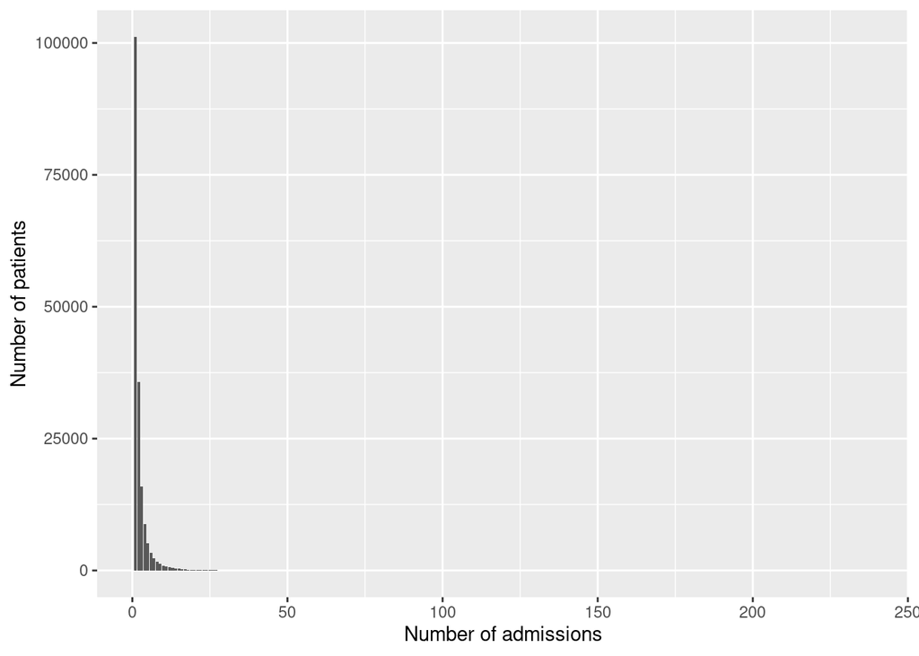

```r
admission_tble |>
  count(subject_id) |>
  ggplot(aes(x = n)) +
  geom_bar() +
  labs(x = "Number of admissions", y = "Number of patients")
```

According to the graph, many of the patients have only one admission. However, there are some patients who have more than one admission. The number of patients with more than one admission decreases as the number of admissions increases. There are even several patients who have more than 50 admissions. Therefore, we need to pay attention to those outliers.

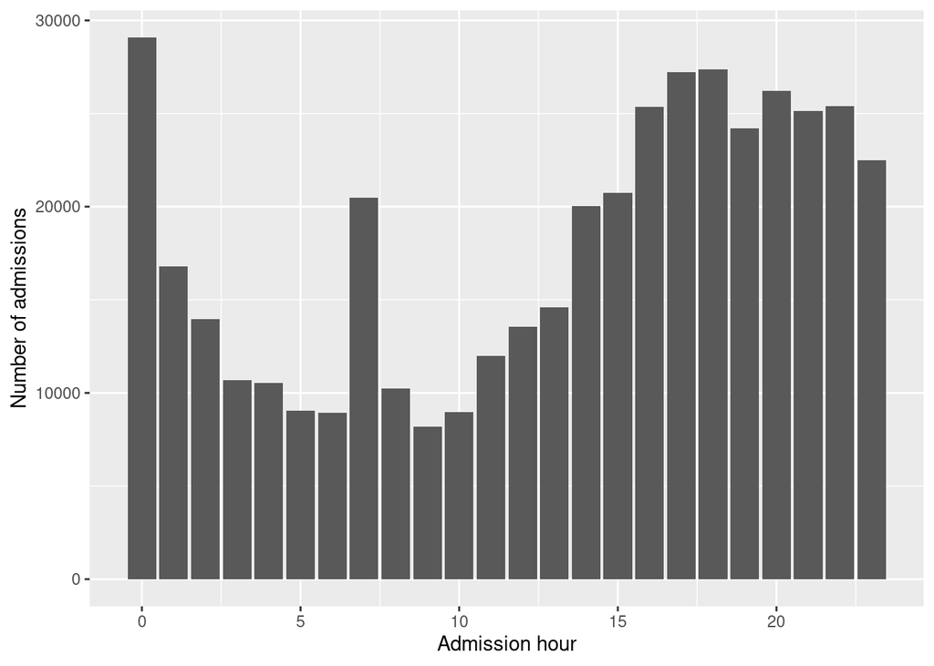

```r
admission_tble |>
  ggplot(aes(x = hour(admittime))) +
  geom_bar() +
  labs(x = "Admission hour", y = "Number of admissions")
```

According to the graph, the number of admissions is relatively low from 1 a.m. to 1 p.m.. It increases from 9 a.m. and decreases from 6 p.m.. The number of admissions has a relatively stable trend except 12 a.m. and 7 a.m., which have higher admissions. I guess the reasons for these two outliers are different. At the midnight there might be some emergency cases, and at 7 a.m. it might be the end of a shift, (The hospital may tend to admit new patients until a new shift starts).

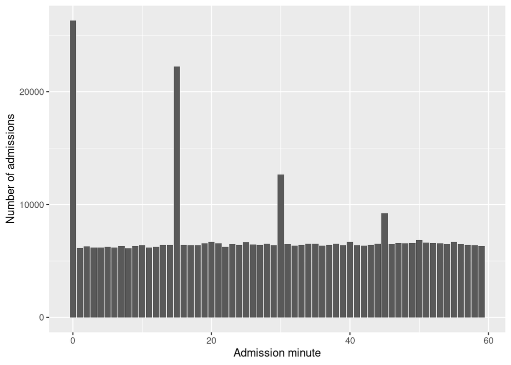

```r
admission_tble |>
  ggplot(aes(x = minute(admittime))) +
  geom_bar() +
  labs(x = "Admission minute", y = "Number of admissions")
```

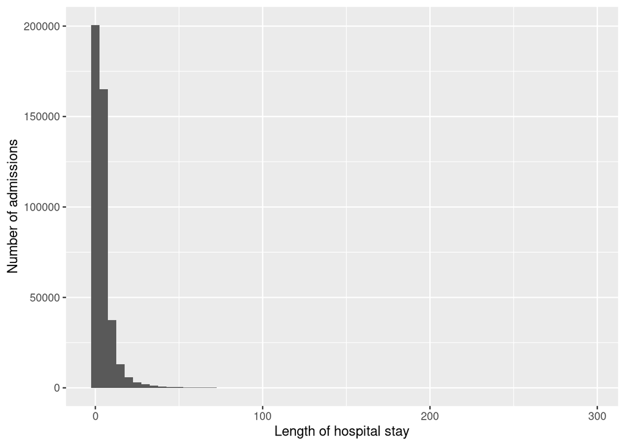

```r
admission_tble |>
  mutate(los = as.numeric(difftime(dischtime, admittime, units = "days"))) |>
  ggplot(aes(x = los)) +
  geom_histogram(binwidth = 5) +
  labs(x = "Length of hospital stay", y = "Number of admissions")
```

According to the graph, most of the patients stay in the hospital for less than 10 days. There are some patients who stay in the hospital for more than 20 days. There are even several patients who stay in the hospital for more than 100 days. Therefore, we need to pay attention to those outliers.

## Q4. `patients` data

Patient information is available in `patients.csv.gz`. See https://mimic.mit.edu/docs/iv/modules/hosp/patients/ for details of each field in this file. The first 10 lines are

```bash
zcat < ~/mimic/hosp/patients.csv.gz | head
```

```
subject_id,gender,anchor_age,anchor_year,anchor_year_group,dod
10000032,F,52,2180,2014 - 2016,2180-09-09
10000048,F,23,2126,2008 - 2010,
10000068,F,19,2160,2008 - 2010,
10000084,M,72,2160,2017 - 2019,2161-02-13
10000102,F,27,2136,2008 - 2010,
10000108,M,25,2163,2014 - 2016,
10000115,M,24,2154,2017 - 2019,
10000117,F,48,2174,2008 - 2010,
10000178,F,59,2157,2017 - 2019,
```

### Q4.1 Ingestion

Import `patients.csv.gz` (https://mimic.mit.edu/docs/iv/modules/hosp/patients/) as a tibble `patients_tble`.

```r
patients_tble <- read_csv("~/mimic/hosp/patients.csv.gz",
                          show_col_types = FALSE)
head(patients_tble, width = Inf)
```

```
# A tibble: 6 × 6
  subject_id gender anchor_age anchor_year anchor_year_group dod
       <dbl> <chr>       <dbl>       <dbl> <chr>             <date>
1   10000032 F              52        2180 2014 - 2016       2180-09-09
2   10000048 F              23        2126 2008 - 2010       NA
3   10000068 F              19        2160 2008 - 2010       NA
4   10000084 M              72        2160 2017 - 2019       2161-02-13
5   10000102 F              27        2136 2008 - 2010       NA
6   10000108 M              25        2163 2014 - 2016       NA
```

### Q4.2 Summary and visualization

Summarize variables `gender` and `anchor_age` by graphics, and explain any patterns you see.

**Answer:**

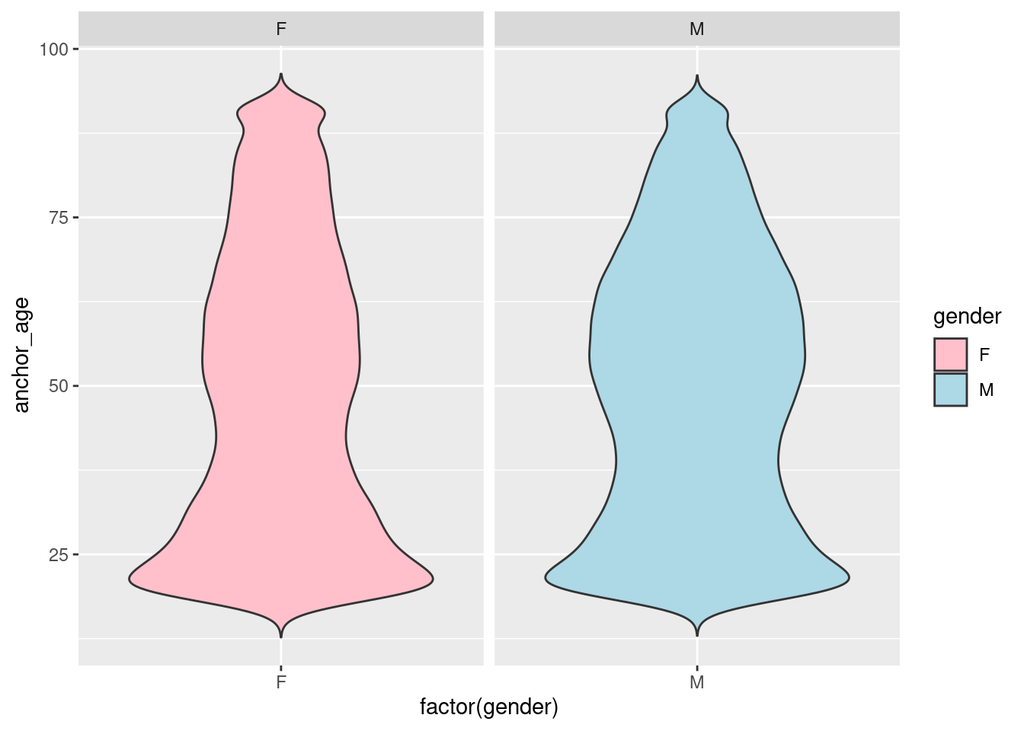

```r
# Use violin plot to show the distribution
patients_tble |>
  ggplot(aes(x = factor(gender), y = anchor_age, fill = gender)) +
  geom_violin(trim = FALSE) +
  scale_fill_manual(values = c("pink","lightblue")) +
  facet_grid(. ~ gender, scales = "free_x")
```

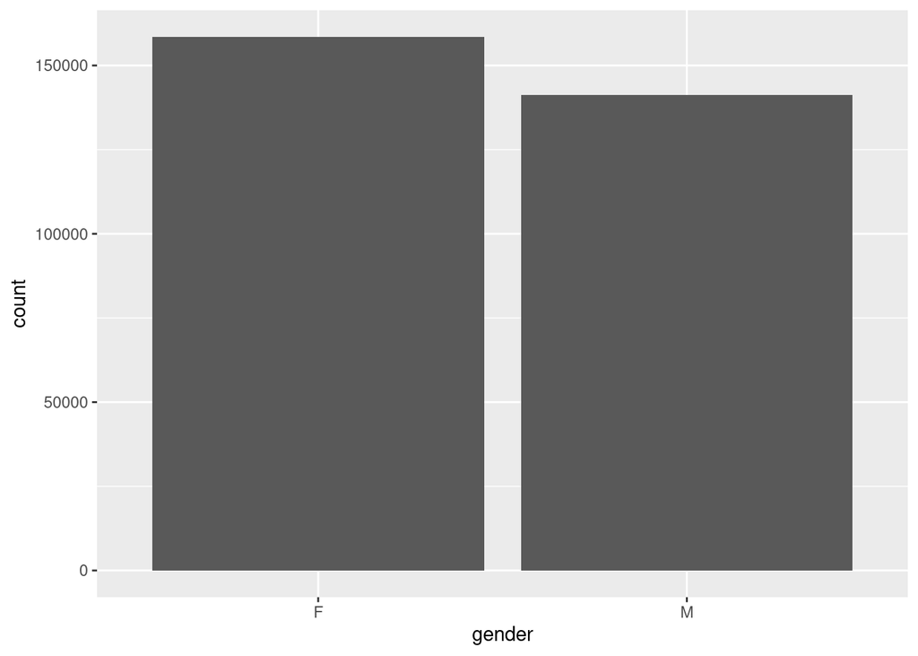

```r
patients_tble |>
  ggplot() +
  geom_bar(aes(x = gender))
```

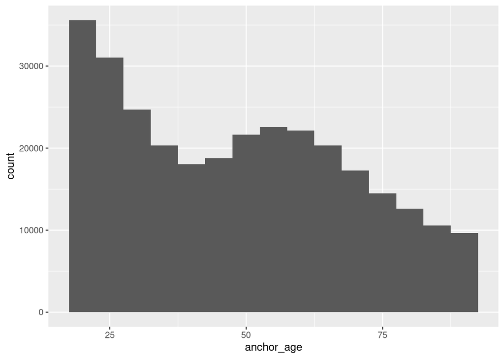

```r
patients_tble |>
  ggplot() +
  geom_histogram(aes(x = anchor_age), binwidth = 5)
```

Notice that there are more female patients than male patients. The age of the patients has two peaks, one is around 60 years old, and the other is around 20 years old. According to the violin graph, the distribution of age is similar for male and female patients.

## Q5. Lab results

`labevents.csv.gz` (https://mimic.mit.edu/docs/iv/modules/hosp/labevents/) contains all laboratory measurements for patients. The first 10 lines are

```bash
zcat < ~/mimic/hosp/labevents.csv.gz | head
```

```
labevent_id,subject_id,hadm_id,specimen_id,itemid,order_provider_id,charttime,storetime,value,valuenum,valueuom,ref_range_lower,ref_range_upper,flag,priority,comments
1,10000032,,45421181,51237,P28Z0X,2180-03-23 11:51:00,2180-03-23 15:15:00,1.4,1.4,,0.9,1.1,abnormal,ROUTINE,
2,10000032,,45421181,51274,P28Z0X,2180-03-23 11:51:00,2180-03-23 15:15:00,___,15.1,sec,9.4,12.5,abnormal,ROUTINE,VERIFIED.
3,10000032,,52958335,50853,P28Z0X,2180-03-23 11:51:00,2180-03-25 11:06:00,___,15,ng/mL,30,60,abnormal,ROUTINE,NEW ASSAY IN USE ___: DETECTS D2 AND D3 25-OH ACCURATELY.
4,10000032,,52958335,50861,P28Z0X,2180-03-23 11:51:00,2180-03-23 16:40:00,102,102,IU/L,0,40,abnormal,ROUTINE,
5,10000032,,52958335,50862,P28Z0X,2180-03-23 11:51:00,2180-03-23 16:40:00,3.3,3.3,g/dL,3.5,5.2,abnormal,ROUTINE,
6,10000032,,52958335,50863,P28Z0X,2180-03-23 11:51:00,2180-03-23 16:40:00,109,109,IU/L,35,105,abnormal,ROUTINE,
7,10000032,,52958335,50864,P28Z0X,2180-03-23 11:51:00,2180-03-23 16:40:00,___,8,ng/mL,0,8.7,,ROUTINE,MEASURED BY ___.
8,10000032,,52958335,50868,P28Z0X,2180-03-23 11:51:00,2180-03-23 16:40:00,12,12,mEq/L,8,20,,ROUTINE,
9,10000032,,52958335,50878,P28Z0X,2180-03-23 11:51:00,2180-03-23 16:40:00,143,143,IU/L,0,40,abnormal,ROUTINE,
```

`d_labitems.csv.gz` (https://mimic.mit.edu/docs/iv/modules/hosp/d_labitems/) is the dictionary of lab measurements.

```bash
zcat < ~/mimic/hosp/d_labitems.csv.gz | head
```

```
itemid,label,fluid,category
50801,Alveolar-arterial Gradient,Blood,Blood Gas
50802,Base Excess,Blood,Blood Gas
50803,"Calculated Bicarbonate, Whole Blood",Blood,Blood Gas
50804,Calculated Total CO2,Blood,Blood Gas
50805,Carboxyhemoglobin,Blood,Blood Gas
50806,"Chloride, Whole Blood",Blood,Blood Gas
50808,Free Calcium,Blood,Blood Gas
50809,Glucose,Blood,Blood Gas
50810,"Hematocrit, Calculated",Blood,Blood Gas
```

We are interested in the lab measurements of creatinine (50912), potassium (50971), sodium (50983), chloride (50902), bicarbonate (50882), hematocrit (51221), white blood cell count (51301), and glucose (50931). Retrieve a subset of `labevents.csv.gz` that only containing these items for the patients in `icustays_tble`. Further restrict to the last available measurement (by `storetime`) before the ICU stay. The final `labevents_tble` should have one row per ICU stay and columns for each lab measurement.

Hint: Use the Parquet format you generated in Homework 2. For reproducibility, make `labevents_pq` folder available at the current working directory `hw3`, for example, by a symbolic link.

```r
icu_id <- icustays_tble |>
  select(subject_id) |>
  distinct()

labevents_tble <- arrow::open_dataset("labevents_pq", format = 'parquet') |>
  select(subject_id, itemid, storetime, valuenum) |>
  filter(itemid %in% c(50912, 50971, 50983, 50902,
                       50882, 51221, 51301, 50931)) |>
  filter(subject_id %in% icu_id$subject_id) |>
  collect() |>
  left_join(icustays_tble[,c("subject_id", "stay_id", "intime")],
            by = "subject_id") |>
  filter(storetime < intime) |>
  group_by(stay_id, itemid) |>
  slice_max(order_by = storetime, n = 1) |>
  ungroup() |>
  select(-c(storetime, intime)) |>
  pivot_wider(names_from = itemid, values_from = valuenum, values_fill = NA) |>
  arrange(subject_id) |>
  rename(creatinine = `50912`, potassium = `50971`, sodium = `50983`,
         chloride = `50902`, bicarbonate = `50882`, hematocrit = `51221`,
         wbc = `51301`, glucose = `50931`) |>
  select(subject_id, stay_id, bicarbonate, chloride, creatinine,
         glucose, potassium, sodium, hematocrit, wbc) |>
  mutate(across(everything(), ~ replace_na(., NA)))
head(labevents_tble, width = Inf)
```

```
# A tibble: 6 × 10
  subject_id  stay_id bicarbonate chloride  creatinine glucose potassium sodium
       <dbl>    <dbl> <list>      <list>    <list>     <list>  <list>    <list>
1   10000032 39553978 <dbl [1]>   <dbl [1]> <dbl [1]>  <dbl>   <dbl [1]> <dbl>
2   10000980 39765666 <dbl [1]>   <dbl [1]> <dbl [1]>  <dbl>   <dbl [1]> <dbl>
3   10001217 34592300 <dbl [1]>   <dbl [1]> <dbl [1]>  <dbl>   <dbl [1]> <dbl>
4   10001217 37067082 <dbl [1]>   <dbl [1]> <dbl [1]>  <dbl>   <dbl [1]> <dbl>
5   10001725 31205490 <NULL>      <dbl [1]> <NULL>     <NULL>  <dbl [1]> <dbl>
6   10001884 37510196 <dbl [1]>   <dbl [1]> <dbl [1]>  <dbl>   <dbl [1]> <dbl>
# ℹ 2 more variables: hematocrit <list>, wbc <list>
```

## Q6. Vitals from charted events

`chartevents.csv.gz` (https://mimic.mit.edu/docs/iv/modules/icu/chartevents/) contains all the charted data available for a patient. During their ICU stay, the primary repository of a patient’s information is their electronic chart. The `itemid` variable indicates a single measurement type in the database. The `value` variable is the value measured for `itemid`. The first 10 lines of `chartevents.csv.gz` are

```bash
zcat < ~/mimic/icu/chartevents.csv.gz | head
```

[output not shown]

`d_items.csv.gz` (https://mimic.mit.edu/docs/iv/modules/icu/d_items/) is the dictionary for the `itemid` in `chartevents.csv.gz`.

```bash
zcat < ~/mimic/icu/d_items.csv.gz | head
```

[output not shown]

We are interested in the vitals for ICU patients: heart rate (220045), systolic non-invasive blood pressure (220179), diastolic non-invasive blood pressure (220180), body temperature in Fahrenheit (223761), and respiratory rate (220210). Retrieve a subset of `chartevents.csv.gz` only containing these items for the patients in `icustays_tble`. Further restrict to the first vital measurement within the ICU stay. The final `chartevents_tble` should have one row per ICU stay and columns for each vital measurement.

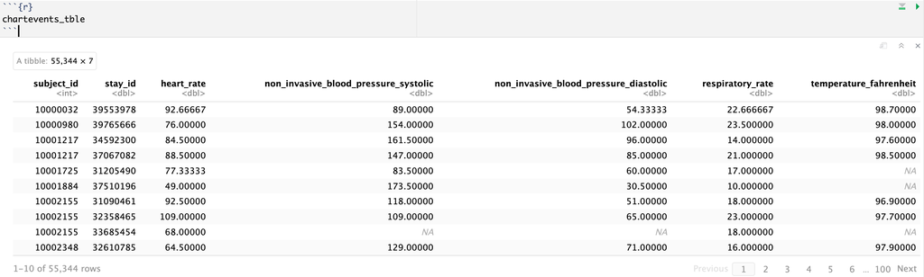

Hint: Use the Parquet format you generated in Homework 2. For reproducibility, make `chartevents_pq` folder available at the current working directory, for example, by a symbolic link.

## Q7. Putting things together

Let us create a tibble `mimic_icu_cohort` for all ICU stays, where rows are all ICU stays of adults (age at `intime` >= 18) and columns contain at least following variables

- all variables in `icustays_tble`
- all variables in `admissions_tble`
- all variables in `patients_tble`
- the last lab measurements before the ICU stay in `labevents_tble`
- the first vital measurements during the ICU stay in `chartevents_tble`

The final `mimic_icu_cohort` should have one row per ICU stay and columns for each variable.

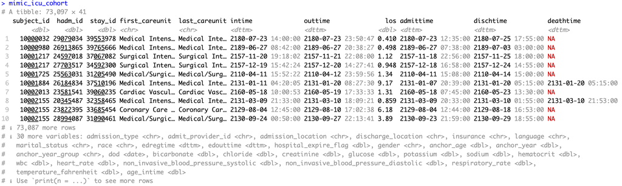

## Q8. Exploratory data analysis (EDA)

Summarize the following information about the ICU stay cohort `mimic_icu_cohort` using appropriate numerics or graphs:

- Length of ICU stay `los` vs demographic variables (race, insurance, marital_status, gender, age at intime)
- Length of ICU stay `los` vs the last available lab measurements before ICU stay
- Length of ICU stay `los` vs the average vital measurements within the first hour of ICU stay
- Length of ICU stay `los` vs first ICU unit